# Lab 6: Functions, Control Flow, dplyr and ggplot2

Stat 133, Fall 2016, Prof. Sanchez

# Preparation for Midterm Project

The goal of this lab is to provide some practice with most of the concepts we have covered so far in the course:

- writing functions
- working with control flow structures
- handling strings
- data manipulation with dplyr
- producing charts with ggplot2

# Women’s High Jump World Record Progression

In this lab you will be working with data of world records in women’s high jump (source Wikipedia). The data set is in the file `womens-high-jump-records.csv` available in the `data/` folder from the github repository:

[https://raw.githubusercontent.com/ucb-stat133/stat133-fall-2016/master/data/womens-high-jump-records.csv](https://raw.githubusercontent.com/ucb-stat133/stat133-fall-2016/master/data/womens-high-jump-records.csv.csv)

Assuming that the data file is already in your working directory, you can use any of the reading table functions to import it in R:

```r
# read data
download.file(
  url = 'https://raw.githubusercontent.com/ucb-stat133/stat133-fall-2016/master/data/womens-high-jump-records.csv',
  destfile = '~/Desktop/STAT 133/stat133-my-repo/lab/womens-high-jump-records.csv')

dat <- read.csv("womens-high-jump-records.csv", stringsAsFactors = FALSE)

# take a peek
head(dat)
```

```
##   height     first       last country day month year
## 1  1.460     Nancy   Voorhees     USA  20   May 1922
## 2  1.485 Elizabeth      Stine     USA  26   May 1923
## 3  1.485    Sophie     Eliott     GBR   6   Aug 1923
## 4  1.524   Phyllis      Green     GBR  11   Jul 1925
## 5  1.552   Phyllis      Green     GBR   2   Aug 1926
## 6  1.580     Ethel Catherwood     CAN   6   Sep 1926
```

The data set has 7 columns:

- height is the height record in meters
- first is the athlete’s first name
- last is the athlete’s last name
- country is the athlete’s country
- day is the day of month (record’s date)
- month is the name of month (record’s date)
- year is the year (record’s date)

## Athlete’s name

The function `paste()`—and its sister `paste0()`—allows you to form character strings by *pasting* any number of vectors:

```r
paste("Go", "Bears", "!")
```

```
## [1] "Go Bears !"
```

```r
paste0("Go", "Bears", "!")
```

```
## [1] "GoBears!"
```

Use `paste()` to create a vector `athlete_name` that shows the athlete’s full name (first and last name)

```r
# your vector athlete_name

athlete_name = paste(dat$first, dat$last)
```

Take your vector `athlete_name`, and use `paste()` again, to create a vector `athlete` in which each element shows the full name followed by the country within parentheses, for example: `Nancy Voorhees (USA)`:

```r
# your vector athlete

athlete_name_country = paste0(athlete_name,' ','(',dat$country,')')
```

## Name of the month

As you can tell, the column `month` has the names of the months in abbreviated format. But what if we want to get the full name? Interestingly, R comes with a built-in vector `month.name` that has the full names of the months (in English). So let’s use `month.name` to write code that converts an abbreviated month into its full name.

For testing purposes, let’s consider one month, say `"Jan"`. One option is to use `switch()`. Complete the following call to `switch()` with the corresponding months, and include an option `NA` at the end for when the input does not match with any of the available switch values. (Make sure to change the chunk option `eval = FALSE` to `eval = TRUE`).

```r
a <- "Jan"

switch(a,
       "Jan" = month.name[1],
       "Feb" = month.name[2],
       "Mar" = month.name[3],
       "Apr" = month.name[4],
       "May" = month.name[5],
       "Jun" = month.name[6],
       "Jul" = month.name[7],
       "Aug" = month.name[8],
       "Sep" = month.name[9],
       "Oct" = month.name[10],
       "Nov" = month.name[11],
       "Dec" = month.name[12]
       )
```

```
## [1] "January"
```

Now encapsulate the `switch()` in a function `expand_month()`. This function takes the abbreviated name, and returns the full name. In the code chunk, add a description of what the function does, what’s the expected input, and what’s the returned value:

```r
# your expand_month() function

# This function is for expanding thenames of the months in abbreviated
# format to full name
expand_month = function(abr){

  switch(abr,
       "Jan" = month.name[1],
       "Feb" = month.name[2],
       "Mar" = month.name[3],
       "Apr" = month.name[4],
       "May" = month.name[5],
       "Jun" = month.name[6],
       "Jul" = month.name[7],
       "Aug" = month.name[8],
       "Sep" = month.name[9],
       "Oct" = month.name[10],
       "Nov" = month.name[11],
       "Dec" = month.name[12],
       "NA"
       )

}

expand_month("Apr")
```

```
## [1] "April"
```

```r
expand_month("Xyz")
```

```
## [1] "NA"
```

```r
# test it with expand_month("Apr") and expand_month("Xyz")
```

### For loop

One option to replace month names is to use a `for` loop. Compute a vector `new_month` by writing a `for` loop that iterates through all the elements in `month`, and switches the value to full name, using `expand_month()`:

```r
new_month = c()
month = dat$month
# your for loop to get new_month
for (abr in month){
  full_name = expand_month(abr)
  new_month = c(new_month, full_name)
}


for (i in 1:nrow(dat)){
  new_month[i] = expand_month(dat$month[i])
}
```

Another alternative is to use one of the functions from the `apply` family: `lapply()` and `sapply()`. Check the documentation for `lapply()` and `sapply()`, and see some examples. Even better, take the column `month`, your `expand_month()` function, and pass them to both `lapply()` and `sapply()` and see what happens:

```r
# use lapply and sapply
lapply(month, function(x) expand_month(x)) # give list
```

```
## [[1]]
## [1] "May"
##
## [[2]]
## [1] "May"
##
## [[3]]
## [1] "August"
##
## [[4]]
## [1] "July"
##
## [[5]]
## [1] "August"
##
## [[6]]
## [1] "September"
##
## [[7]]
## [1] "July"
##
## [[8]]
## [1] "August"
##
## [[9]]
## [1] "August"
##
## [[10]]
## [1] "June"
##
## [[11]]
## [1] "August"
##
## [[12]]
## [1] "August"
##
## [[13]]
## [1] "May"
##
## [[14]]
```

[output cut: 112 more lines]

```
##
## [[52]]
## [1] "June"
##
## [[53]]
## [1] "July"
##
## [[54]]
## [1] "May"
##
## [[55]]
## [1] "May"
##
## [[56]]
## [1] "August"
```

```r
sapply(month, function(x) expand_month(x)) # names vector
```

```
##         May         May         Aug         Jul         Aug         Sep
##       "May"       "May"    "August"      "July"    "August" "September"
##         Jul         Aug         Aug         Jun         Aug         Aug
##      "July"    "August"    "August"      "June"    "August"    "August"
##         May         Mar         Jul         May         Jul         May
##       "May"     "March"      "July"       "May"      "July"       "May"
##         May         Jul         Dec         Oct         Nov         Jun
##       "May"      "July"  "December"   "October"  "November"      "June"
##         Jun         Jul         Oct         Oct         Sep         Jun
##      "June"      "July"   "October"   "October" "September"      "June"
##         Jul         Apr         Jun         Jul         Jul         Sep
##      "July"     "April"      "June"      "July"      "July" "September"
##         Sep         Sep         Aug         Sep         May         Jul
## "September" "September"    "August" "September"       "May"      "July"
##         Aug         Aug         Aug         Aug         Aug         Sep
##    "August"    "August"    "August"    "August"    "August" "September"
##         Aug         Aug         Aug         Jun         Jul         May
##    "August"    "August"    "August"      "June"      "July"       "May"
##         May         Aug
##       "May"    "August"
```

Build a vector `full_month` with the full name:

```r
# your vector full_month
full_month = sapply(month, function(x) expand_month(x))
```

## Record dates

Take the vectors `full_month`, `day`, and `year`, and `paste()` them—in that order—to build a vector `record_dates` with the format `"May-20-1922", "May-26-1923", ...`

```r
# your vector record_dates
record_dates = paste(full_month, dat$day, dat$year, sep = "-")
```

Your vector `record_dates` is just a character vector. But you can use it to get a vector of class `"Date"`. Check the documentation of the function `as.Date()` in order to reformat your vector `record_dates` with `"%B-%d-%Y"` format:

```r
# date formatting
# complete as necessary: record_dates <- as.Date(record_dates, ...)

record_dates2 <- as.Date(record_dates, format = "%B-%d-%Y")
```

Apply `paste()` one more time to the vectors `day`, `full_month`, and `year`, in this order, to build a vector `dates`: e.g. `"20 May 1922", "26 May 1923", ...`

```r
# your vector dates

dates = paste(dat$day, full_month, dat$year)
```

Use `as.Date()` one more time to reformat your vector `dates` with `"%d %B %Y"` format:

```r
# date formatting
# complete as necessary: dates <- as.Date(dates, ...)

dates2 = as.Date(dates, format = "%d %B %Y")
```

# Derived Data Frame

The next task consists of building a new data frame `womens` using the vectors `height`, `athlete_name`, `country`, and `date`. When building the data frame use the following column names:

- `Height = height`
- `Athlete = athlete_name`
- `Country = country`
- `Date = dates`

```r
# your data frame "womens"
```

# Manipulating data with `"dplyr"`

Let’s do some data manipulation and aggregation with the R package `"dplyr"`:

```r
library(dplyr)
```

Begin by extracting the distinct (unique) countries:

```r
# distinct countries
```

The column `height` in the original data frame `dat` is in meters. You can use `transmute()` to compute a vector `height_inches` (1 meter = 39.3701 inches):

```r
# compute vector of height in inches
```

Likewise, you can use the function `mutate()` to add a new column `height_inches` to `dat`:

```r
# add column height_inches to dat
```

Take the original data frame `dat` and use `"dplyr"` to compute the:

- number of records per country
- number of records per country in decreasing order
- number of records per year
- number of records per year in decresing order

```r
# records per country

# records per country in descending order

# records per year

# records per year in descending order
```

Now take the data frame `womens` and use `"dplyr"` to compute the:

- number of records per athlete
- number of records per athlete in decreasing order

```r
# number of records per country

# number of records per country in decreasing order
```

# Visualizing Records with `"ggplot2"`

Now that you have the `dat` and `womens` data frame, let’s use `"ggplot2"` to get some plots:

```r
library(ggplot2)
```

Take `dat` and get a bar-chart with the number of records per country, with bars in descending order:

```r
# your scatterplot
```

Now take `womens` and use `geom_point()` to get a scatterplot of `x = Date` and `y = Height`. Add a title `"Women's High Jump Record Progression"`.

```r
# your scatterplot
```

Now add a line, you can try using `geom_line()`

```r
# scatterplot with line
```

Instead of adding a simple line, use the `geom_step()` line:

```r
# scatterplot with step line
```

Now use `Country` to color the points

```r
# scatterplot with step line, color points by country
```

\newpage

# Solutions

```r
# vector athlete_name
athlete_name <- paste(dat$first, dat$last)

# vector athlete
athlete <- paste0(athlete_name, " (", dat$country, ")")

# month in full name
a <- "Jan"

switch(a,
       "Jan" = month.name[1],
       "Feb" = month.name[2],
       "Mar" = month.name[3],
       "Apr" = month.name[4],
       "May" = month.name[5],
       "Jun" = month.name[6],
       "Jul" = month.name[7],
       "Aug" = month.name[8],
       "Sep" = month.name[9],
       "Oct" = month.name[10],
       "Nov" = month.name[11],
       "Dec" = month.name[12],
       NA)
```

```
## [1] "January"
```

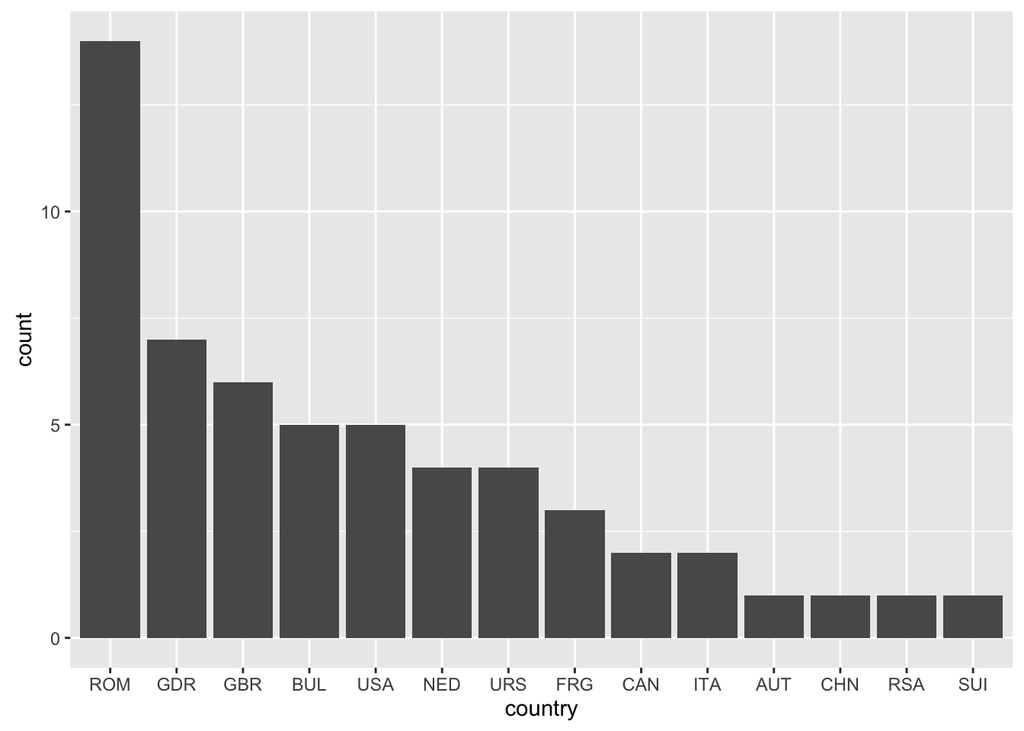

```r
# your expand_month() function
expand_month <- function(mon = 'Jan') {
  switch(mon,
       "Jan" = month.name[1],
       "Feb" = month.name[2],
       "Mar" = month.name[3],
       "Apr" = month.name[4],
       "May" = month.name[5],
       "Jun" = month.name[6],
       "Jul" = month.name[7],
       "Aug" = month.name[8],
       "Sep" = month.name[9],
       "Oct" = month.name[10],
       "Nov" = month.name[11],
       "Dec" = month.name[12],
       NA)
}


# Your for loop to get new_month
# 1st) initialize an empty character vector
new_month <- character(length(dat$month))

# now the loop
for (m in 1:length(dat$month)) {
  new_month[m] <- expand_month(dat$month[m])
}


# use lapply and sapply to get full name of month
lapply_month <- lapply(dat$month, expand_month)
sapply_month <- sapply(dat$month, expand_month)

# vector full_month
full_month <- sapply(dat$month, expand_month)

# vector record_dates
record_dates <- paste(full_month, dat$day, dat$year, sep = "-")

# reformat record_dates
record_dates <- as.Date(record_dates, "%B-%d-%Y")

# vector dates
dates <- paste(dat$day, full_month, dat$year)

# reformat dates
dates <- as.Date(dates, "%d %B %Y")

# data frame "womens"
womens <- data.frame(
  Height = dat$height,
  Athlete = athlete_name,
  Country = dat$country,
  Date = dates
)


# ================================================================
# Data Manipulation with dplyr
# ================================================================

# distinct countries
unique_countries <- dat %>% distinct(country)

# compute vector of height in inches
height_inches <- transmute(dat, height_inches = height * 39.3701)

# add column height_inches to 'dat'
dat <- mutate(dat, height_inches = height * 39.3701)

# records per country
per_country <- dat %>%
  group_by(country) %>%
  summarise(records = n())

# records per country in descending order
per_country_desc <- per_country %>%
  arrange(desc(records))

# records per year
per_year <- dat %>%
  group_by(year) %>%
  summarise(records = n())

# records per year in descending order
per_year_desc <- per_year %>%
  arrange(desc(records))


# records per athlete
per_athlete <- womens %>%
  group_by(Athlete) %>%
  summarise(records = n())

# number of records per country in decreasing order
per_athlete_desc <- per_country %>%
  arrange(desc(records))


# ================================================================
# Data Visualiztion with ggplot2
# ================================================================

# bar-chart with the number of records per country:
# to order the bars, you can use scale_x_discrete() and specify
# the order of the bars
ggplot(dat, aes(x = country)) +
  geom_bar() +
  scale_x_discrete(limits = per_country_desc$country)
```

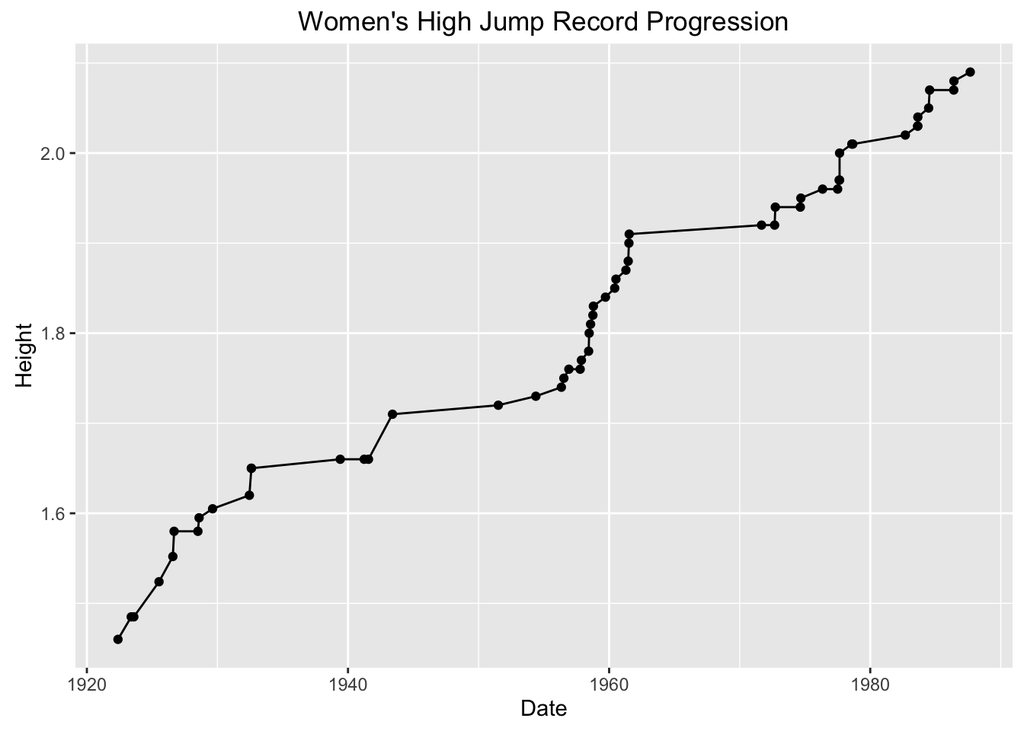

```r
# ggplot object (for convenient purposes and save retyping)
progression <- ggplot(data = womens, aes(x = Date, y = Height)) +
  ggtitle("Women's High Jump Record Progression")

# scatterplot with line
progression + geom_line() + geom_point()
```

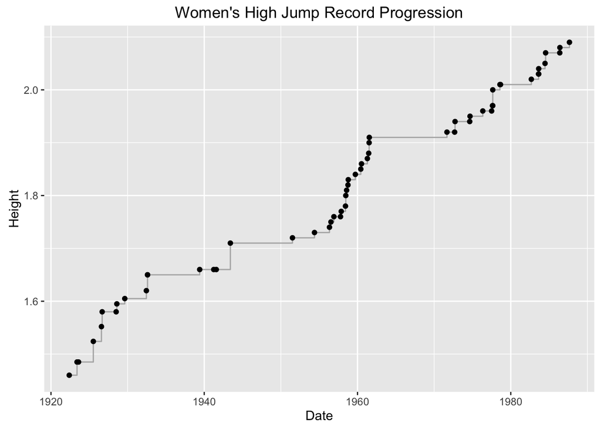

```r
# scatterplot with step line
progression + geom_step(color = "gray70") + geom_point()
```

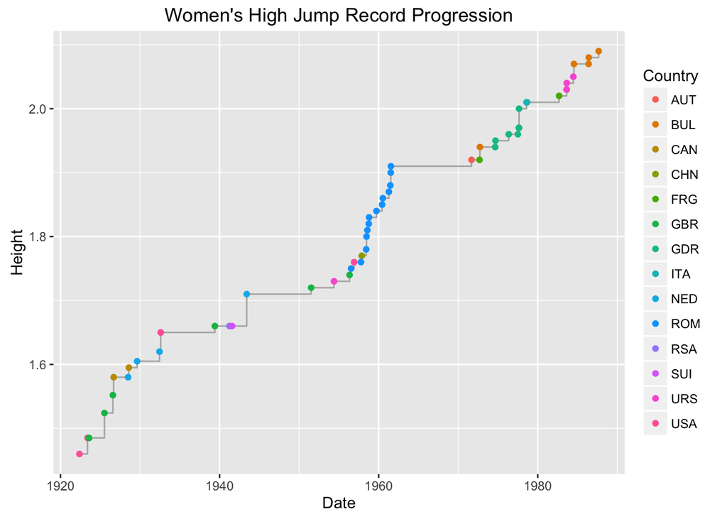

```r
# scatterplot with step line, color points by country
progression +
  geom_step(color = "gray70") +
  geom_point(aes(color = Country))
```